# bayesian linear regression

# Data Preprocessing

the data set used is about medical cost personal the following are the variabels contained in the data

- age: age of primary beneficiary
- sex: insurance contractor gender, female, male
- bmi: Body mass index, providing an understanding of body, weights that are relatively high or low relative to height, objective index of body weight (kg / m ^ 2) using the ratio of height to weight, ideally 18.5 to 24.9
- children: Number of children covered by health insurance / Number of dependents
- smoker: Smoking
- region: the beneficiary’s residential area in the US, northeast, southeast, southwest, northwest.
- charges: Individual medical costs billed by health insurance

importing data

```
'data.frame':   1338 obs. of  7 variables:
 $ age     : int  19 18 28 33 32 31 46 37 37 60 ...
 $ sex     : Factor w/ 2 levels \female\,\male\: 1 2 2 2 2 1 1 1 2 1 ...
 $ bmi     : num  27.9 33.8 33 22.7 28.9 ...
 $ children: int  0 1 3 0 0 0 1 3 2 0 ...
 $ smoker  : Factor w/ 2 levels \no\,\yes\: 2 1 1 1 1 1 1 1 1 1 ...
 $ region  : Factor w/ 4 levels \northeast\,\northwest\,..: 4 3 3 2 2 3 3 2 1 2 ...
 $ charges : num  16885 1726 4449 21984 3867 ...
```

```
      age            sex           bmi           children     smoker
 Min.   :18.00   female:662   Min.   :15.96   Min.   :0.000   no :1064
 1st Qu.:27.00   male  :676   1st Qu.:26.30   1st Qu.:0.000   yes: 274
 Median :39.00                Median :30.40   Median :1.000
 Mean   :39.21                Mean   :30.66   Mean   :1.095
 3rd Qu.:51.00                3rd Qu.:34.69   3rd Qu.:2.000
 Max.   :64.00                Max.   :53.13   Max.   :5.000
       region       charges
 northeast:324   Min.   : 1122
 northwest:325   1st Qu.: 4740
 southeast:364   Median : 9382
 southwest:325   Mean   :13270
                 3rd Qu.:16640
                 Max.   :63770
```

importing packages

```r
#install.packages('gridExtra')
#install.packages("tidyverse")
library(tidyverse)
library(gridExtra) # to plot multiple ggplots aside
library(car) # package for regression diagnostics
```

plot.bmi <- ggplot(insurance, aes(x = bmi, y = charges)) + geom_point()

grid.arrange(plot.age, plot.bmi, ncol=2)

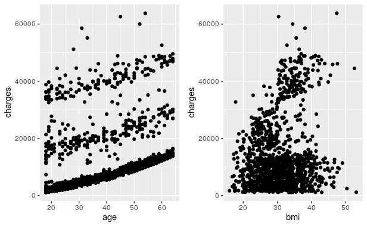

```r
age1 <- ggplot(insurance, aes(x = age, y = charges,col=sex)) + geom_point()
age2 <- ggplot(insurance, aes(x = age, y = charges,col=bmi)) + geom_point()
age3 <- ggplot(insurance, aes(x = age, y = charges,col=children)) + geom_point()
age4 <- ggplot(insurance, aes(x = age, y = charges,col=smoker)) + geom_point()
age5 <- ggplot(insurance, aes(x = age, y = charges,col=region)) + geom_point()
grid.arrange(age1,age2,age3,age4,age5,ncol=2)
```

[figure not shown]

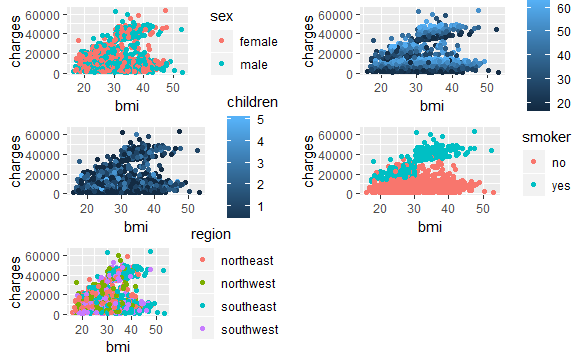

```r
bmi1 <- ggplot(insurance, aes(x = bmi, y = charges,col=sex)) + geom_point()
bmi2 <- ggplot(insurance, aes(x = bmi, y = charges,col=age)) + geom_point()
bmi3 <- ggplot(insurance, aes(x = bmi, y = charges,col=children)) + geom_point()
bmi4 <- ggplot(insurance, aes(x = bmi, y = charges,col=smoker)) + geom_point()
bmi5 <- ggplot(insurance, aes(x = bmi, y = charges,col=region)) + geom_point()
grid.arrange(bmi1,bmi2,bmi3,bmi4,bmi5,ncol=2)
```

[figure not shown]

plot.smoker <- ggplot(insurance, aes(x = smoker, y = charges)) + geom_boxplot()

plot.child <- ggplot(insurance, aes(x = as.factor(children), y = charges)) + geom_boxplot()

plot.region <- ggplot(insurance, aes(x = region, y = charges)) + geom_boxplot()

grid.arrange(plot.sex, plot.smoker, plot.child, plot.region, ncol=2, nrow=2)

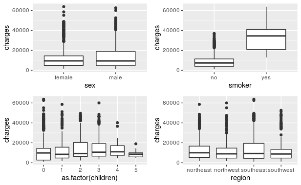

# Ordinary Regression

```r
mod <- lm(charges ~ . ,data=insurance)
summary(mod)
```

```
Call:
lm(formula = charges ~ ., data = insurance)

Residuals:
     Min       1Q   Median       3Q      Max
-11304.9  -2848.1   -982.1   1393.9  29992.8

Coefficients:
                Estimate Std. Error t value Pr(>|t|)
(Intercept)     -11938.5      987.8 -12.086  < 2e-16 ***
age                256.9       11.9  21.587  < 2e-16 ***
sexmale           -131.3      332.9  -0.394 0.693348
bmi                339.2       28.6  11.860  < 2e-16 ***
children           475.5      137.8   3.451 0.000577 ***
smokeryes        23848.5      413.1  57.723  < 2e-16 ***
regionnorthwest   -353.0      476.3  -0.741 0.458769
regionsoutheast  -1035.0      478.7  -2.162 0.030782 *
regionsouthwest   -960.0      477.9  -2.009 0.044765 *
---
Signif. codes:  0 ‘***’ 0.001 ‘**’ 0.01 ‘*’ 0.05 ‘.’ 0.1 ‘ ’ 1

Residual standard error: 6062 on 1329 degrees of freedom
Multiple R-squared:  0.7509,    Adjusted R-squared:  0.7494
F-statistic: 500.8 on 8 and 1329 DF,  p-value: < 2.2e-16
```

```r
#m <- lm(charges~age*bmi*children*smoker*region*smoker*bmi)
#sm <- step(m)
#summary(sm)
#terlalalu komplit
```

final model used

```r
mod2 <- lm(charges ~ age + bmi + children + smoker + region + smoker*bmi, data=insurance)
summary(mod2)
```

```
Call:
lm(formula = charges ~ age + bmi + children + smoker + region +
    smoker * bmi, data = insurance)

Residuals:
     Min       1Q   Median       3Q      Max
-14655.4  -1918.9  -1313.4   -489.7  30333.1

Coefficients:
                  Estimate Std. Error t value Pr(>|t|)
(Intercept)      -2453.564    857.695  -2.861  0.00429 **
age                264.042      9.522  27.729  < 2e-16 ***
bmi                 22.615     25.620   0.883  0.37756
children           512.713    110.266   4.650 3.65e-06 ***
smokeryes       -20309.092   1648.861 -12.317  < 2e-16 ***
regionnorthwest   -581.704    381.215  -1.526  0.12727
regionsoutheast  -1207.011    383.109  -3.151  0.00167 **
regionsouthwest  -1227.601    382.576  -3.209  0.00136 **
bmi:smokeryes     1438.108     52.630  27.325  < 2e-16 ***
---
Signif. codes:  0 ‘***’ 0.001 ‘**’ 0.01 ‘*’ 0.05 ‘.’ 0.1 ‘ ’ 1

Residual standard error: 4851 on 1329 degrees of freedom
Multiple R-squared:  0.8405,    Adjusted R-squared:  0.8395
F-statistic: 875.4 on 8 and 1329 DF,  p-value: < 2.2e-16
```

# OLS with matrix

```r
#variabel definition
y <- charges
x1 <- age
x2 <- sex
x3 <- bmi
x4 <- children
x5 <- smoker
x6 <- region
x1x5 <- age*as.numeric(smoker)
x3x5 <- bmi*as.numeric(smoker)
```

```r
mod1 <- lm(y ~ x1+x2+x3+x4+x5+x6+x1x5 + x3x5)
summary(mod1)
```

[output not shown]

# Inference Parameter linear Regression with Bayesian Approach

```r
mod2 <- lm(y ~ x1+ x3 + x4 +x5 +x6 +x3x5)
summary(mod2)
```

```
Call:
lm(formula = y ~ x1 + x3 + x4 + x5 + x6 + x3x5)

Residuals:
     Min       1Q   Median       3Q      Max
-14655.4  -1918.9  -1313.4   -489.7  30333.1

Coefficients:
              Estimate Std. Error t value Pr(>|t|)
(Intercept)  -2453.564    857.695  -2.861  0.00429 **
x1             264.042      9.522  27.729  < 2e-16 ***
x3           -1415.493     68.145 -20.772  < 2e-16 ***
x4             512.713    110.266   4.650 3.65e-06 ***
x5yes       -20309.092   1648.861 -12.317  < 2e-16 ***
x6northwest   -581.704    381.215  -1.526  0.12727
x6southeast  -1207.011    383.109  -3.151  0.00167 **
x6southwest  -1227.601    382.576  -3.209  0.00136 **
x3x5          1438.108     52.630  27.325  < 2e-16 ***
---
Signif. codes:  0 ‘***’ 0.001 ‘**’ 0.01 ‘*’ 0.05 ‘.’ 0.1 ‘ ’ 1

Residual standard error: 4851 on 1329 degrees of freedom
Multiple R-squared:  0.8405,    Adjusted R-squared:  0.8395
F-statistic: 875.4 on 8 and 1329 DF,  p-value: < 2.2e-16
```

```r
X <- as.matrix(cbind(rep(1,length(y)),x1,x3,x4,as.numeric(x5),as.numeric(x6),x3x5))
dim(X)
```

```
[1] 1338    7
```

```r
n <- dim(X)[1]
k <- dim(X)[2]
```

```r
#prior parameter
nu0 <- 1
s20 <- summary(mod2)$sigma^2 #prior variation from ols
g <- n
```

```r
#posterior calclation
Hg <- (g/(g+1))*X%*%solve(t(X)%*%X)%*%t(X)
SSRg<- t(y)%*%(diag(1,nrow=n)-Hg)%*%y

Vbeta <- g*solve(t(X)%*%X)/(g+1)
Ebeta <- Vbeta %*% t(X) %*% y
```

```r
#monte Carlo

n<-dim(X)[1];
p<-dim(X)[2]
Hg<-(g/(g+1))*X%*%solve(t(X)%*%X)%*%t(X)
SSRg<- t(y)%*%(diag(1,nrow=n)-Hg)%*%y
s2<-1/rgamma(S,(nu0+n)/2,(nu0*s20+SSRg/2)) #gamma sample
Vb<-g*solve(t(X)%*%X)/(g+1)
Eb<-Vb%*%t(X)%*%y
E<- matrix(rnorm(S*p,0,sqrt(s2)),S,p) #sample beta
```

```r
beta<-t(t(E%*%chol(Vb))+c(Eb))
```

```r
b <- colSums(beta)/S
b
```

```
                     x1          x3          x4
 18278.4004    264.0786  -1418.5028    520.5275 -20296.2891
                   x3x5
  -424.6490   1436.4384
```

[figure not shown]

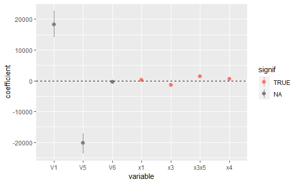

```r
library(tidyr)
library(dplyr)
library(ggplot2)

signif = apply(beta, MARGIN = 2, FUN = quantile, probs = c(0.025, 0.5, 0.975)) %>%
  apply(MARGIN = 2, FUN = function(y) !(y[1] < 0 && 0 < y[3]))

beta_df = as.data.frame(beta) %>%
  gather(key = 'variable', val = 'coefficient') %>%
  mutate(signif = signif[variable])

ggplot(beta_df, aes(x = variable, y = coefficient, color = signif)) +
  stat_summary(fun.y = mean, fun.ymin = function(y) quantile(y, probs = c(0.025)), fun.ymax = function(y) quantile(y, probs = c(0.975))) +
  geom_hline(yintercept = 0, lty = 2)
```